# CAPUA_PRESANA_TSF

## Time Series

```python
import warnings
import itertools
import numpy as np
import matplotlib.pyplot as plt
warnings.filterwarnings("ignore")
plt.style.use('fivethirtyeight')
import pandas as pd
import statsmodels.api as sm
import matplotlib

matplotlib.rcParams['axes.labelsize'] = 14
matplotlib.rcParams['xtick.labelsize'] = 12
matplotlib.rcParams['ytick.labelsize'] = 12
matplotlib.rcParams['text.color'] = 'k'
```

We are going to do time series analysis and forecasting for furniture sales.

```python
df = pd.read_excel("/content/Sample - Superstore.xls")
furniture = df.loc[df['Category'] == 'Furniture']
```

We have a good 4-year furniture sales data.

```python
furniture['Order Date'].min()
```

```
Timestamp('2014-01-06 00:00:00')
```

```python
furniture['Order Date'].max()
```

```
Timestamp('2017-12-30 00:00:00')
```

# Data preprocessing

This step includes removing columns we do not need, check missing values, aggregate sales by date and so on.

```python
cols = ['Row ID', 'Order ID', 'Ship Date', 'Ship Mode', 'Customer ID', 'Customer Name', 'Segment', 'Country', 'City', 'State', 'Postal Code', 'Region', 'Product ID', 'Category', 'Sub-Category', 'Product Name', 'Quantity', 'Discount', 'Profit']
furniture.drop(cols, axis=1, inplace=True)
furniture = furniture.sort_values('Order Date')
```

```python
furniture.isnull().sum()
```

```
Order Date    0
Sales         0
dtype: int64
```

```python
furniture = furniture.groupby('Order Date')['Sales'].sum().reset_index()
```

```python
furniture.head()
```

|  | Order Date | Sales |
| --- | --- | --- |
| 0 | 2014-01-06 | 2573.820 |
| 1 | 2014-01-07 | 76.728 |
| 2 | 2014-01-10 | 51.940 |
| 3 | 2014-01-11 | 9.940 |
| 4 | 2014-01-13 | 879.939 |

Indexing with time series data

```python
furniture = furniture.set_index('Order Date')
furniture.index
```

```
DatetimeIndex(['2014-01-06', '2014-01-07', '2014-01-10', '2014-01-11',
               '2014-01-13', '2014-01-14', '2014-01-16', '2014-01-19',
               '2014-01-20', '2014-01-21',
               ...
               '2017-12-18', '2017-12-19', '2017-12-21', '2017-12-22',
               '2017-12-23', '2017-12-24', '2017-12-25', '2017-12-28',
               '2017-12-29', '2017-12-30'],
              dtype='datetime64[ns]', name='Order Date', length=889, freq=None)
```

Our current datetime data can be tricky to work with, therefore, we will use the averages daily sales value for that month instead, and we are using the start of each month as the timestamp.

```python
y = furniture['Sales'].resample('MS').mean()
```

```python
y['2017':]
```

```
Order Date
2017-01-01     397.602133
2017-02-01     528.179800
2017-03-01     544.672240
2017-04-01     453.297905
2017-05-01     678.302328
2017-06-01     826.460291
2017-07-01     562.524857
2017-08-01     857.881889
2017-09-01    1209.508583
2017-10-01     875.362728
2017-11-01    1277.817759
2017-12-01    1256.298672
Freq: MS, Name: Sales, dtype: float64
```

# Visualizing furniture sales time series data

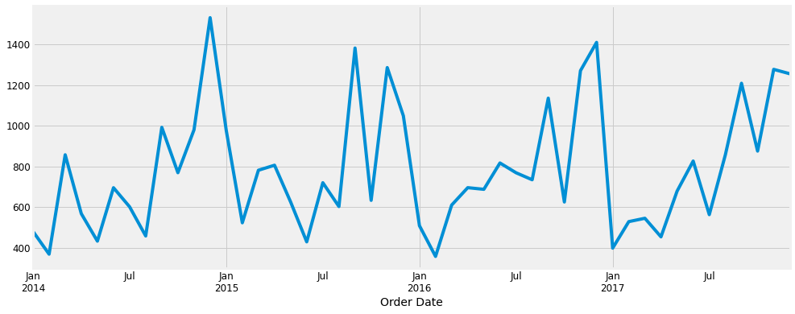

```python
y.plot(figsize=(15, 6))
plt.show()
```

We can also visualize our data using a method called time-series decomposition that allows us to decompose our time series into three distinct components: trend, seasonality, and noise.

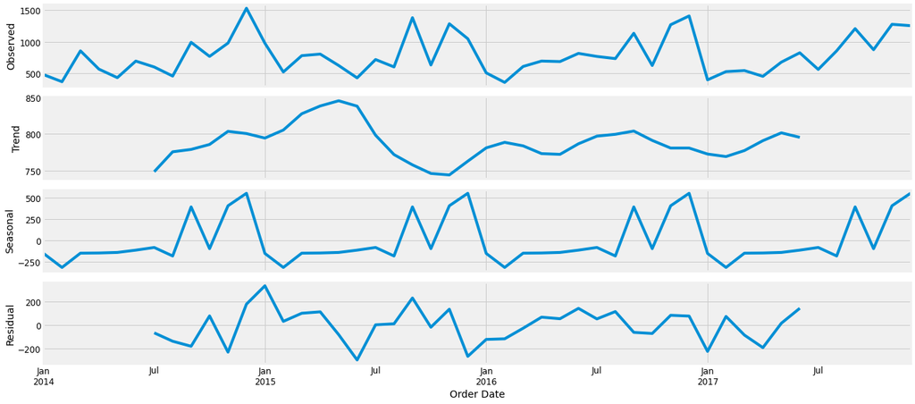

```python
from pylab import rcParams
rcParams['figure.figsize'] = 18, 8

decomposition = sm.tsa.seasonal_decompose(y, model='additive')
fig = decomposition.plot()
plt.show()
```

The plot above clearly shows that the sales of furniture is unstable, along with its obvious seasonality.

# Time series forecasting with ARIMA

We are going to apply one of the most commonly used method for time-series forecasting, known as ARIMA, which stands for Autoregressive Integrated Moving Average.

Parameter Selection for the ARIMA Time Series Model

```python
p = d = q = range(0, 2)
pdq = list(itertools.product(p, d, q))
seasonal_pdq = [(x[0], x[1], x[2], 12) for x in list(itertools.product(p, d, q))]

print('Examples of parameter combinations for Seasonal ARIMA...')
print('SARIMAX: {} x {}'.format(pdq[1], seasonal_pdq[1]))
print('SARIMAX: {} x {}'.format(pdq[1], seasonal_pdq[2]))
print('SARIMAX: {} x {}'.format(pdq[2], seasonal_pdq[3]))
print('SARIMAX: {} x {}'.format(pdq[2], seasonal_pdq[4]))
```

```
Examples of parameter combinations for Seasonal ARIMA...
SARIMAX: (0, 0, 1) x (0, 0, 1, 12)
SARIMAX: (0, 0, 1) x (0, 1, 0, 12)
SARIMAX: (0, 1, 0) x (0, 1, 1, 12)
SARIMAX: (0, 1, 0) x (1, 0, 0, 12)
```

```python
for param in pdq:
    for param_seasonal in seasonal_pdq:
        try:
            mod = sm.tsa.statespace.SARIMAX(y,
                                            order=param,
                                            seasonal_order=param_seasonal,
                                            enforce_stationarity=False,
                                            enforce_invertibility=False)

            results = mod.fit()

            print('ARIMA{}x{}12 - AIC:{}'.format(param, param_seasonal, results.aic))
        except:
            continue
```

```
ARIMA(0, 0, 0)x(0, 0, 0, 12)12 - AIC:769.0817523205916
ARIMA(0, 0, 0)x(0, 0, 1, 12)12 - AIC:1291.1586461285508
ARIMA(0, 0, 0)x(0, 1, 0, 12)12 - AIC:477.71701309202774
ARIMA(0, 0, 0)x(1, 0, 0, 12)12 - AIC:497.2314433418337
```

```
ARIMA(0, 0, 0)x(1, 0, 1, 12)12 - AIC:1341.4774825752884
ARIMA(0, 0, 0)x(1, 1, 0, 12)12 - AIC:318.0047199116341
ARIMA(0, 0, 1)x(0, 0, 0, 12)12 - AIC:720.9252270758116
ARIMA(0, 0, 1)x(0, 0, 1, 12)12 - AIC:2890.3956414293407
ARIMA(0, 0, 1)x(0, 1, 0, 12)12 - AIC:466.5607429809134
```

```
ARIMA(0, 0, 1)x(1, 0, 0, 12)12 - AIC:499.5815754980983
ARIMA(0, 0, 1)x(1, 0, 1, 12)12 - AIC:2592.49103021319
ARIMA(0, 0, 1)x(1, 1, 0, 12)12 - AIC:319.98848769468657
ARIMA(0, 1, 0)x(0, 0, 0, 12)12 - AIC:677.894766843944
```

```
ARIMA(0, 1, 0)x(0, 0, 1, 12)12 - AIC:1354.9157815720205
ARIMA(0, 1, 0)x(0, 1, 0, 12)12 - AIC:486.6378567198382
ARIMA(0, 1, 0)x(1, 0, 0, 12)12 - AIC:497.78896630044073
```

```
ARIMA(0, 1, 0)x(1, 0, 1, 12)12 - AIC:1006.8019521666
ARIMA(0, 1, 0)x(1, 1, 0, 12)12 - AIC:319.7714068109211
ARIMA(0, 1, 1)x(0, 0, 0, 12)12 - AIC:649.9056176817193
ARIMA(0, 1, 1)x(0, 0, 1, 12)12 - AIC:2534.1807038393567
ARIMA(0, 1, 1)x(0, 1, 0, 12)12 - AIC:458.8705548482836
ARIMA(0, 1, 1)x(1, 0, 0, 12)12 - AIC:486.1832977442613
ARIMA(0, 1, 1)x(1, 0, 1, 12)12 - AIC:2359.5912392244145
ARIMA(0, 1, 1)x(1, 1, 0, 12)12 - AIC:310.7574368417338
ARIMA(1, 0, 0)x(0, 0, 0, 12)12 - AIC:692.1645522067712
ARIMA(1, 0, 0)x(0, 0, 1, 12)12 - AIC:1450.898321496226
ARIMA(1, 0, 0)x(0, 1, 0, 12)12 - AIC:479.46321478521355
```

```
ARIMA(1, 0, 0)x(1, 0, 0, 12)12 - AIC:480.9259367935194
ARIMA(1, 0, 0)x(1, 0, 1, 12)12 - AIC:1262.338613078044
ARIMA(1, 0, 0)x(1, 1, 0, 12)12 - AIC:304.4664675084582
ARIMA(1, 0, 1)x(0, 0, 0, 12)12 - AIC:665.7794442185634
ARIMA(1, 0, 1)x(0, 0, 1, 12)12 - AIC:2665.6367167733683
ARIMA(1, 0, 1)x(0, 1, 0, 12)12 - AIC:468.3685195815885
ARIMA(1, 0, 1)x(1, 0, 0, 12)12 - AIC:482.5763323876976
```

```
ARIMA(1, 0, 1)x(1, 0, 1, 12)12 - AIC:2536.9149846409973
ARIMA(1, 0, 1)x(1, 1, 0, 12)12 - AIC:306.01560020902036
ARIMA(1, 1, 0)x(0, 0, 0, 12)12 - AIC:671.2513547541902
ARIMA(1, 1, 0)x(0, 0, 1, 12)12 - AIC:1508.5821409861014
ARIMA(1, 1, 0)x(0, 1, 0, 12)12 - AIC:479.20034222811347
ARIMA(1, 1, 0)x(1, 0, 0, 12)12 - AIC:475.3403658784957
```

```
ARIMA(1, 1, 0)x(1, 0, 1, 12)12 - AIC:1331.2919470409036
ARIMA(1, 1, 0)x(1, 1, 0, 12)12 - AIC:300.6270901345411
ARIMA(1, 1, 1)x(0, 0, 0, 12)12 - AIC:649.0318019835603
```

```
ARIMA(1, 1, 1)x(0, 0, 1, 12)12 - AIC:2537.4523401808897
ARIMA(1, 1, 1)x(0, 1, 0, 12)12 - AIC:460.47626876093364
ARIMA(1, 1, 1)x(1, 0, 0, 12)12 - AIC:469.5250354660756
```

```
ARIMA(1, 1, 1)x(1, 0, 1, 12)12 - AIC:nan
ARIMA(1, 1, 1)x(1, 1, 0, 12)12 - AIC:297.7875439533909
```

```python
mod = sm.tsa.statespace.SARIMAX(y,
                                order=(1, 1, 1),
                                seasonal_order=(1, 1, 0, 12),
                                enforce_stationarity=False,
                                enforce_invertibility=False)

results = mod.fit()

print(results.summary().tables[1])
```

```
==============================================================================
                 coef    std err          z      P>|z|      [0.025      0.975]
------------------------------------------------------------------------------
ar.L1          0.0146      0.342      0.043      0.966      -0.655       0.684
ma.L1         -1.0000      0.360     -2.781      0.005      -1.705      -0.295
ar.S.L12      -0.0253      0.042     -0.609      0.543      -0.107       0.056
sigma2      2.958e+04   1.22e-05   2.43e+09      0.000    2.96e+04    2.96e+04
==============================================================================
```

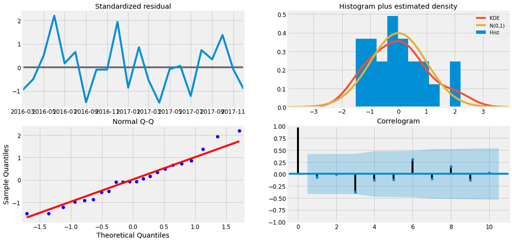

```python
results.plot_diagnostics(figsize=(16, 8))
plt.show()
```

# Validating forecasts

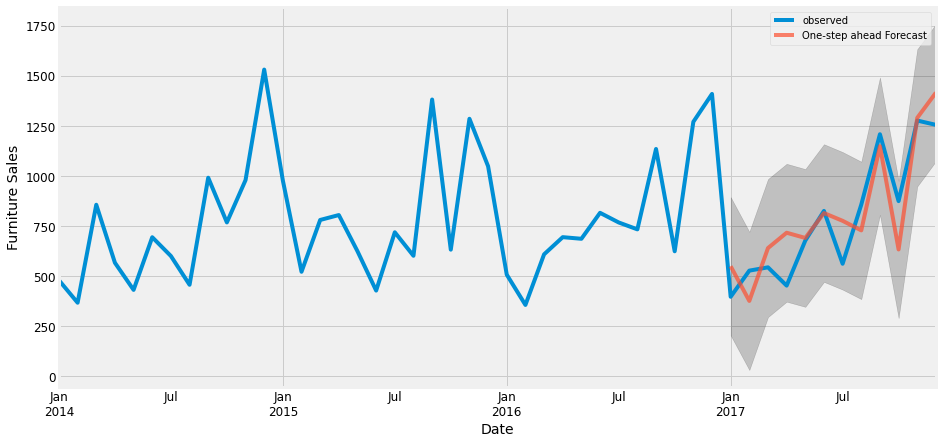

```python
pred = results.get_prediction(start=pd.to_datetime('2017-01-01'), dynamic=False)
pred_ci = pred.conf_int()

ax = y['2014':].plot(label='observed')
pred.predicted_mean.plot(ax=ax, label='One-step ahead Forecast', alpha=.7, figsize=(14, 7))

ax.fill_between(pred_ci.index,
                pred_ci.iloc[:, 0],
                pred_ci.iloc[:, 1], color='k', alpha=.2)

ax.set_xlabel('Date')
ax.set_ylabel('Furniture Sales')
plt.legend()

plt.show()
```

The line plot is showing the observed values compared to the rolling forecast predictions. Overall, our forecasts align with the true values very well, showing an upward trend starts from the beginning of the year.

```python
y_forecasted = pred.predicted_mean
y_truth = y['2017-01-01':]

# Compute the mean square error
mse = ((y_forecasted - y_truth) ** 2).mean()
print('The Mean Squared Error of our forecasts is {}'.format(round(mse, 2)))
```

```
The Mean Squared Error of our forecasts is 22993.57
```

```python
print('The Root Mean Squared Error of our forecasts is {}'.format(round(np.sqrt(mse), 2)))
```

```
The Root Mean Squared Error of our forecasts is 151.64
```

In statistics, the mean squared error (MSE) of an estimator measures the average of the squares of the errors — that is, the average squared difference between the estimated values and what is estimated. The MSE is a measure of the quality of an estimator—it is always non-negative, and the smaller the MSE, the closer we are to finding the line of best fit.

Root Mean Square Error (RMSE) tells us that our model was able to forecast the average daily furniture sales in the test set within 151.64 of the real sales. Our furniture daily sales range from around 400 to over 1200. In my opinion, this is a pretty good model so far.

# Producing and visualizing forecasts

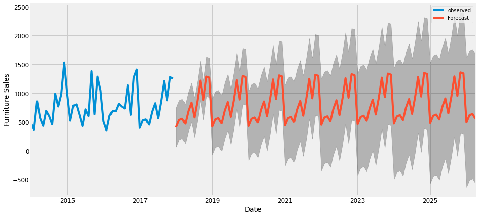

```python
pred_uc = results.get_forecast(steps=100)
pred_ci = pred_uc.conf_int()

ax = y.plot(label='observed', figsize=(14, 7))
pred_uc.predicted_mean.plot(ax=ax, label='Forecast')
ax.fill_between(pred_ci.index,
                pred_ci.iloc[:, 0],
                pred_ci.iloc[:, 1], color='k', alpha=.25)
ax.set_xlabel('Date')
ax.set_ylabel('Furniture Sales')

plt.legend()
plt.show()
```

Our model clearly captured furniture sales seasonality. As we forecast further out into the future, it is natural for us to become less confident in our values. This is reflected by the confidence intervals generated by our model, which grow larger as we move further out into the future.

The above time series analysis for furniture makes me curious about other categories, and how do they compare with each other onver time. Therefore, we are going to compare time series of furniture and office supplier.

# Time Series comparison furniture sales and Office Supplies

Data Preprocessing

```python
furniture = df.loc[df['Category'] == 'Furniture']
office = df.loc[df['Category'] == 'Office Supplies']
```

```python
furniture.shape, office.shape
```

```
((2121, 21), (6026, 21))
```

```python
cols = ['Row ID', 'Order ID', 'Ship Date', 'Ship Mode', 'Customer ID', 'Customer Name', 'Segment', 'Country', 'City', 'State', 'Postal Code', 'Region', 'Product ID', 'Category', 'Sub-Category', 'Product Name', 'Quantity', 'Discount', 'Profit']
furniture.drop(cols, axis=1, inplace=True)
office.drop(cols, axis=1, inplace=True)

furniture = furniture.sort_values('Order Date')
office = office.sort_values('Order Date')

furniture = furniture.groupby('Order Date')['Sales'].sum().reset_index()
office = office.groupby('Order Date')['Sales'].sum().reset_index()
```

```python
furniture.head()
```

|  | Order Date | Sales |
| --- | --- | --- |
| 0 | 2014-01-06 | 2573.820 |
| 1 | 2014-01-07 | 76.728 |
| 2 | 2014-01-10 | 51.940 |
| 3 | 2014-01-11 | 9.940 |
| 4 | 2014-01-13 | 879.939 |

```python
office.head()
```

|  | Order Date | Sales |
| --- | --- | --- |
| 0 | 2014-01-03 | 16.448 |
| 1 | 2014-01-04 | 288.060 |
| 2 | 2014-01-05 | 19.536 |
| 3 | 2014-01-06 | 685.340 |
| 4 | 2014-01-07 | 10.430 |

# Data exploration

We are going to compare two categories' sales in the same time period. This means combine two data frames into one and plot these two categories' time series into one plot.

```python
furniture = furniture.set_index('Order Date')
office = office.set_index('Order Date')

y_furniture = furniture['Sales'].resample('MS').mean()
y_office = office['Sales'].resample('MS').mean()

furniture = pd.DataFrame({'Order Date':y_furniture.index, 'Sales':y_furniture.values})
office = pd.DataFrame({'Order Date': y_office.index, 'Sales': y_office.values})

store = furniture.merge(office, how='inner', on='Order Date')
store.rename(columns={'Sales_x': 'furniture_sales', 'Sales_y': 'office_sales'}, inplace=True)
store.head()
```

|  | Order Date | furniture_sales | office_sales |
| --- | --- | --- | --- |
| 0 | 2014-01-01 | 480.194231 | 285.357647 |
| 1 | 2014-02-01 | 367.931600 | 63.042588 |
| 2 | 2014-03-01 | 857.291529 | 391.176318 |
| 3 | 2014-04-01 | 567.488357 | 464.794750 |
| 4 | 2014-05-01 | 432.049188 | 324.346545 |

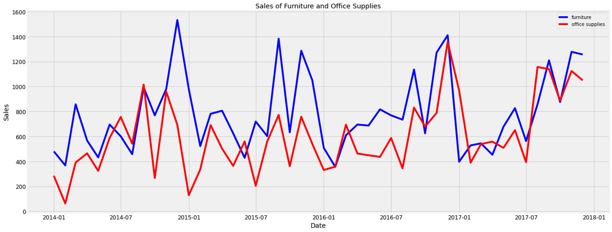

```python
plt.figure(figsize=(20, 8))
plt.plot(store['Order Date'], store['furniture_sales'], 'b-', label = 'furniture')
plt.plot(store['Order Date'], store['office_sales'], 'r-', label = 'office supplies')
plt.xlabel('Date'); plt.ylabel('Sales'); plt.title('Sales of Furniture and Office Supplies')
plt.legend();
```

# Time Series Modeling with Prophet

Released by Facebook in 2017, forecasting tool Prophet is designed for analyzing time-series that display patterns on different time scales such as yearly, weekly and daily. It also has advanced capabilities for modeling the effects of holidays on a time-series and implementing custom changepoints. Therefore, we are using Prophet to get a model up and running.

```python
from fbprophet import Prophet

furniture = furniture.rename(columns={'Order Date': 'ds', 'Sales': 'y'})
furniture_model = Prophet(interval_width=0.95)
furniture_model.fit(furniture)

office = office.rename(columns={'Order Date': 'ds', 'Sales': 'y'})
office_model = Prophet(interval_width=0.95)
office_model.fit(office)
```

```
INFO:fbprophet:Disabling weekly seasonality. Run prophet with weekly_seasonality=True to override this.
INFO:fbprophet:Disabling daily seasonality. Run prophet with daily_seasonality=True to override this.
INFO:fbprophet:Disabling weekly seasonality. Run prophet with weekly_seasonality=True to override this.
INFO:fbprophet:Disabling daily seasonality. Run prophet with daily_seasonality=True to override this.
```

```
<fbprophet.forecaster.Prophet at 0x7fed184d3090>
```

```python
furniture_forecast = furniture_model.make_future_dataframe(periods=36, freq='MS')
furniture_forecast = furniture_model.predict(furniture_forecast)

office_forecast = office_model.make_future_dataframe(periods=36, freq='MS')
office_forecast = office_model.predict(office_forecast)
```

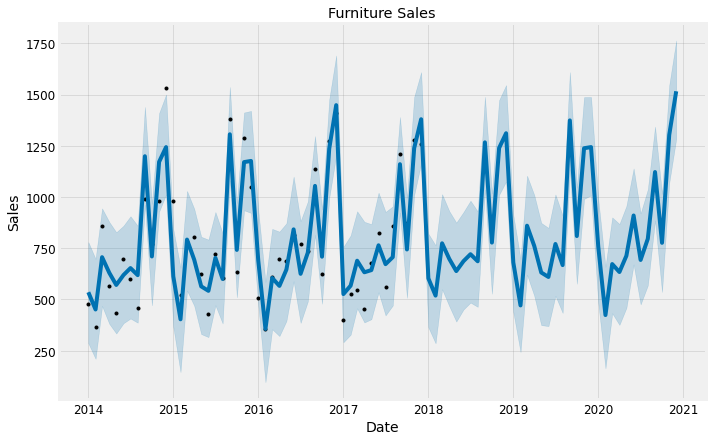

```python
plt.figure(figsize=(18, 6))
furniture_model.plot(furniture_forecast, xlabel = 'Date', ylabel = 'Sales')
plt.title('Furniture Sales');
```

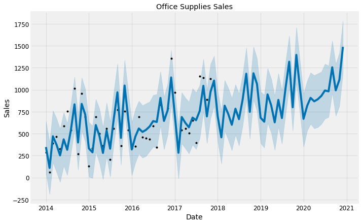

```python
plt.figure(figsize=(18, 6))
office_model.plot(office_forecast, xlabel = 'Date', ylabel = 'Sales')
plt.title('Office Supplies Sales');
```

# Compare Forecasts

We already have the forecasts for three years for these two categories into the future. We will now join them together to compare their future forecasts.

```python
furniture_names = ['furniture_%s' % column for column in furniture_forecast.columns]
office_names = ['office_%s' % column for column in office_forecast.columns]

merge_furniture_forecast = furniture_forecast.copy()
merge_office_forecast = office_forecast.copy()

merge_furniture_forecast.columns = furniture_names
merge_office_forecast.columns = office_names

forecast = pd.merge(merge_furniture_forecast, merge_office_forecast, how = 'inner', left_on = 'furniture_ds', right_on = 'office_ds')

forecast = forecast.rename(columns={'furniture_ds': 'Date'}).drop('office_ds', axis=1)
forecast.head()
```

|  | Date | furniture_trend | furniture_yhat_lower | furniture_yhat_upper | furniture_trend_lower | furniture_trend_upper | furniture_additive_terms | furniture_additive_terms_lower | furniture_additive_terms_upper | furniture_yearly | furniture_yearly_lower | furniture_yearly_upper | furniture_multiplicative_terms | furniture_multiplicative_terms_lower | furniture_multiplicative_terms_upper | furniture_yhat | office_trend | office_yhat_lower | office_yhat_upper | office_trend_lower | office_trend_upper | office_additive_terms | office_additive_terms_lower | office_additive_terms_upper | office_yearly | office_yearly_lower | office_yearly_upper | office_multiplicative_terms | office_multiplicative_terms_lower | … |
| --- | --- | --- | --- | --- | --- | --- | --- | --- | --- | --- | --- | --- | --- | --- | --- | --- | --- | --- | --- | --- | --- | --- | --- | --- | --- | --- | --- | --- | --- | --- |
| 0 | 2014-01-01 | 726.057713 | 286.103024 | 779.744022 | 726.057713 | 726.057713 | -190.685662 | -190.685662 | -190.685662 | -190.685662 | -190.685662 | -190.685662 | 0.0 | 0.0 | 0.0 | 535.372051 | 487.530759 | 45.812622 | 641.522313 | 487.530759 | 487.530759 | -140.040481 | -140.040481 | -140.040481 | -140.040481 | -140.040481 | -140.040481 | 0.0 | 0.0 | … |
| 1 | 2014-02-01 | 727.494023 | 210.547317 | 697.975677 | 727.494023 | 727.494023 | -276.377703 | -276.377703 | -276.377703 | -276.377703 | -276.377703 | -276.377703 | 0.0 | 0.0 | 0.0 | 451.116320 | 494.918445 | -188.805192 | 404.559113 | 494.918445 | 494.918445 | -385.678283 | -385.678283 | -385.678283 | -385.678283 | -385.678283 | -385.678283 | 0.0 | 0.0 | … |
| 2 | 2014-03-01 | 728.791335 | 468.495899 | 944.398532 | 728.791335 | 728.791335 | -22.389755 | -22.389755 | -22.389755 | -22.389755 | -22.389755 | -22.389755 | 0.0 | 0.0 | 0.0 | 706.401580 | 501.591193 | 172.376326 | 763.618725 | 501.591193 | 501.591193 | -31.379844 | -31.379844 | -31.379844 | -31.379844 | -31.379844 | -31.379844 | 0.0 | 0.0 | … |
| 3 | 2014-04-01 | 730.227645 | 381.230238 | 877.910588 | 730.227645 | 730.227645 | -100.141158 | -100.141158 | -100.141158 | -100.141158 | -100.141158 | -100.141158 | 0.0 | 0.0 | 0.0 | 630.086487 | 508.978878 | 61.992632 | 674.081775 | 508.978878 | 508.978878 | -134.291690 | -134.291690 | -134.291690 | -134.291690 | -134.291690 | -134.291690 | 0.0 | 0.0 | … |
| 4 | 2014-05-01 | 731.617622 | 334.020730 | 827.750177 | 731.617622 | 731.617622 | -160.815662 | -160.815662 | -160.815662 | -160.815662 | -160.815662 | -160.815662 | 0.0 | 0.0 | 0.0 | 570.801960 | 516.128251 | -51.995717 | 553.824077 | 516.128251 | 516.128251 | -263.821569 | -263.821569 | -263.821569 | -263.821569 | -263.821569 | -263.821569 | 0.0 | 0.0 | … |

Visualizing the trend and the forecast

```
WARNING:matplotlib.legend:No handles with labels found to put in legend.
```

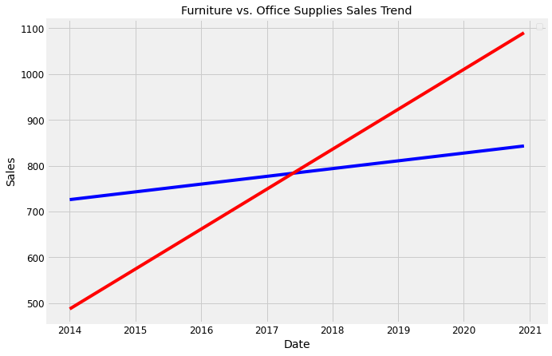

```python
plt.figure(figsize=(10, 7))
plt.plot(forecast['Date'], forecast['furniture_trend'], 'b-')
plt.plot(forecast['Date'], forecast['office_trend'], 'r-')
plt.legend(); plt.xlabel('Date'); plt.ylabel('Sales')
plt.title('Furniture vs. Office Supplies Sales Trend');
```

```
WARNING:matplotlib.legend:No handles with labels found to put in legend.
```

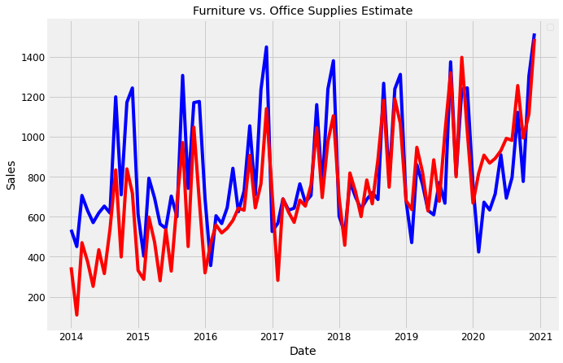

```python
plt.figure(figsize=(10, 7))
plt.plot(forecast['Date'], forecast['furniture_yhat'], 'b-')
plt.plot(forecast['Date'], forecast['office_yhat'], 'r-')
plt.legend(); plt.xlabel('Date'); plt.ylabel('Sales')
plt.title('Furniture vs. Office Supplies Estimate');
```

# Trends and Patterns

Now, we can use the Prophet Models to inspect different trends of these two categories in the data.

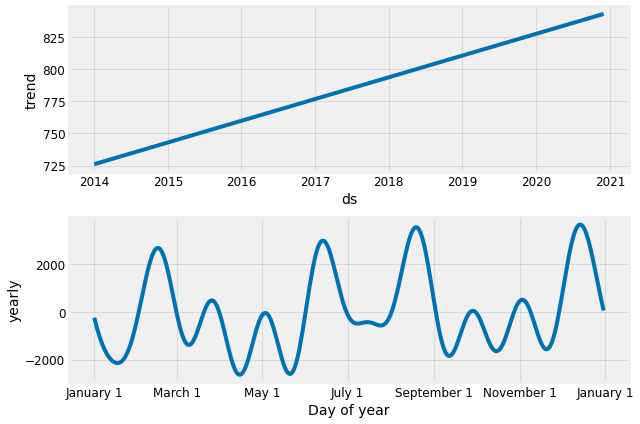

```python
furniture_model.plot_components(furniture_forecast);
```

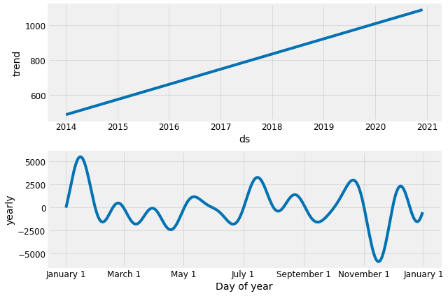

```python
office_model.plot_components(office_forecast);
```

There are many time-series analysis we can explore from now on, such as forecast with uncertainty bounds, change point and anomaly detection, forecast time-series with external data source. We have only scratched the surface here. Stay tuned for future works on time-series analysis.

CONVERT to pdf

```python
!git clone https://github.com/jupyter/nbconvert.git
```

[output not shown]

```python
!pip install -e .
```

```
ERROR: File "setup.py" or "setup.cfg" not found. Directory cannot be installed in editable mode: /content
```

```python
!apt-get install pandoc
```

```
Reading package lists... Done
Building dependency tree
Reading state information... Done
pandoc is already the newest version (1.19.2.4~dfsg-1build4).
pandoc set to manually installed.
0 upgraded, 0 newly installed, 0 to remove and 37 not upgraded.
```

```python
!apt-get update
!apt-get install inkscape
!add-apt-repository universe
!add-apt-repository ppa:inkscape.dev/stable
!apt-get update
!apt install inkscape
```

[output not shown]

[output cut: 590 more lines]

[output not shown]

```python
!apt-get install texlive-xetex texlive-fonts-recommended texlive-generic-recommended
```

[output not shown]

[output cut: 198 more lines]

[output not shown]

```python
!jupyter nbconvert --to pdf 'CAPUA_PRESANA_TSF.ipynb'
```

[output not shown]